# Homework 01

Author

Steven Jia

Published

August 30, 2026

## Question 1: Least squares and matrix calculations

I generated the data with NumPy’s reproducible random-number generator. I used `np.linalg.lstsq`, which is based on a stable least-squares factorization rather than explicitly forming $(X^{\mathsf T}X)^{-1}$.

```python
rng = np.random.default_rng(43201)
n, p = 100, 5
x = rng.normal(size=(n, p))
X = np.column_stack([np.ones(n), x])
beta = np.array([3.0, 1.4, -0.9, 0.7, 0.0, 1.1])
epsilon = rng.normal(loc=0.0, scale=0.7, size=n)
y = X @ beta + epsilon

beta_hat, _, rank, _ = np.linalg.lstsq(X, y, rcond=None)
fitted = X @ beta_hat
residuals = y - fitted
training_rmse = np.sqrt(np.mean(residuals**2))
normal_equation_error = np.max(np.abs(X.T @ residuals))

coef_comparison = pd.DataFrame({
    "coefficient": ["intercept", "x1", "x2", "x3", "x4", "x5"],
    "truth": beta,
    "estimate": beta_hat,
})
display(coef_comparison.round(4))
print("Dimensions of X:", X.shape)
print("Rank of X:", rank)
print(f"Training RMSE: {training_rmse:.6f}")
print(f"||X^T r||_infinity: {normal_equation_error:.3e}")
```

|  | coefficient | truth | estimate |
| --- | --- | --- | --- |
| 0 | intercept | 3.0 | 2.9731 |
| 1 | x1 | 1.4 | 1.3240 |
| 2 | x2 | -0.9 | -0.8415 |
| 3 | x3 | 0.7 | 0.7204 |
| 4 | x4 | 0.0 | -0.0831 |
| 5 | x5 | 1.1 | 1.1651 |

```
Dimensions of X: (100, 6)
Rank of X: 6
Training RMSE: 0.646340
||X^T r||_infinity: 1.485e-12
```

The design matrix is $100\times6$ because it contains an intercept and five predictors, and it has full column rank 6. The estimates are reasonably close to the generating coefficients, but not identical because this sample contains random noise. The training RMSE is about 0.646, close to the error standard deviation 0.7. Finally, $\lVert X^{\mathsf T}r\rVert_\infty$ is at numerical roundoff level. The least-squares first-order condition is $X^{\mathsf T}r=0$, so the residual vector is orthogonal to every column of $X$. Orthogonality to the intercept column also means the residuals sum to approximately zero.

## Question 2: Gaussian likelihood

### (a) Relationship to least squares

For fixed $\sigma^2$, the term $-n\log(2\pi\sigma^2)/2$ is constant in $\boldsymbol\beta$, while the residual sum of squares is multiplied by the negative constant $-1/(2\sigma^2)$. Therefore maximizing the log-likelihood over $\boldsymbol\beta$ is exactly the same as minimizing RSS, and $\widehat{\boldsymbol\beta}_{\mathrm{MLE}}=\widehat{\boldsymbol\beta}_{\mathrm{LS}}$.

### (b) Variance estimates

Write $v=\sigma^2$ and $RSS(\boldsymbol\beta)=\lVert y-X\boldsymbol\beta\rVert^2$. Then

$$\frac{\partial \ell}{\partial v}
=-\frac{n}{2v}+\frac{RSS(\boldsymbol\beta)}{2v^2}.$$

Setting this derivative to zero gives $\widehat\sigma^2_{\mathrm{MLE}}=RSS(\widehat\beta)/n$. The usual unbiased estimator instead divides by $n-6$ because six regression coefficients were estimated, leaving $n-6$ residual degrees of freedom.

```python
rss = residuals @ residuals
sigma2_mle = rss / n
sigma2_unbiased = rss / (n - X.shape[1])
print(f"RSS: {rss:.6f}")
print(f"MLE variance (RSS/n): {sigma2_mle:.6f}")
print(f"Unbiased variance (RSS/(n-6)): {sigma2_unbiased:.6f}")
```

```
RSS: 41.775504
MLE variance (RSS/n): 0.417755
Unbiased variance (RSS/(n-6)): 0.444420
```

The MLE is smaller because it does not adjust for the six fitted coefficients.

### (c) Likelihood slice

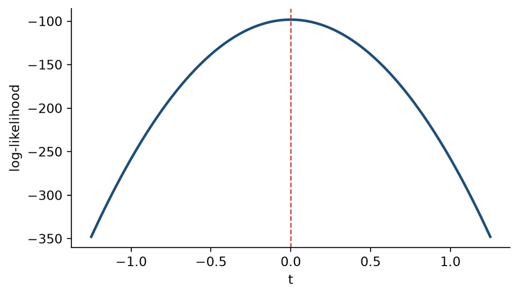

Log-likelihood when only the x2 coefficient is moved away from its least-squares estimate.

```
Grid maximum occurs at t = 0.000
```

```python
e_x2 = np.array([0.0, 0.0, 1.0, 0.0, 0.0, 0.0])
t_grid = np.linspace(-1.25, 1.25, 501)

def fixed_variance_loglik(t):
    trial_beta = beta_hat + t * e_x2
    trial_residual = y - X @ trial_beta
    trial_rss = trial_residual @ trial_residual
    return (-n / 2 * np.log(2 * np.pi * sigma2_mle)
            - trial_rss / (2 * sigma2_mle))

loglik_values = np.array([fixed_variance_loglik(t) for t in t_grid])
t_at_max = t_grid[np.argmax(loglik_values)]

fig, ax = plt.subplots(figsize=(6.2, 3.4))
ax.plot(t_grid, loglik_values, color="#1f4e79", linewidth=2)
ax.axvline(0, color="#c43c35", linestyle="--", linewidth=1)
ax.set(xlabel="t", ylabel="log-likelihood")
ax.spines[["top", "right"]].set_visible(False)
plt.show()
print(f"Grid maximum occurs at t = {t_at_max:.3f}")
```

The maximum occurs at $t=0$, so moving the $x_2$ coefficient in either direction lowers the likelihood. This agrees with the least-squares result because $\widehat\beta$ minimizes RSS and therefore maximizes the Gaussian likelihood for fixed variance.

## Question 3: Starting values in nonconvex optimization

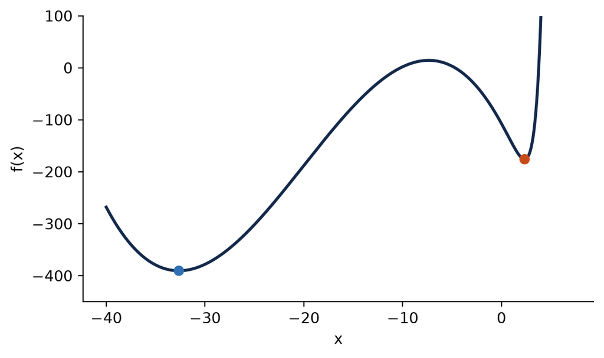

The nonconvex objective and the two BFGS solutions. The vertical scale is limited so both minima are visible.

|  | start | final_x | f(final_x) | absolute_gradient | converged |
| --- | --- | --- | --- | --- | --- |
| 0 | -15.0 | -32.649111 | -390.38577 | 0.000000 | True |
| 1 | 0.0 | 2.349967 | -175.86262 | 0.000008 | True |

```python
def objective(x):
    return np.exp(1.5 * x) - 3 * (x + 6)**2 - 0.05 * x**3

def gradient(x):
    return 1.5 * np.exp(1.5 * x) - 6 * (x + 6) - 0.15 * x**2

x_grid = np.linspace(-40, 7, 1200)
starts = [-15.0, 0.0]
results = []
for start in starts:
    result = minimize(
        fun=lambda z: objective(z[0]),
        x0=np.array([start]),
        jac=lambda z: np.array([gradient(z[0])]),
        method="BFGS",
    )
    results.append(result)

summary = pd.DataFrame({
    "start": starts,
    "final_x": [r.x[0] for r in results],
    "f(final_x)": [r.fun for r in results],
    "absolute_gradient": [abs(gradient(r.x[0])) for r in results],
    "converged": [r.success for r in results],
})

fig, ax = plt.subplots(figsize=(6.2, 3.5))
ax.plot(x_grid, objective(x_grid), color="#13294b", linewidth=2)
ax.scatter([r.x[0] for r in results], [r.fun for r in results],
           color=["#2f6fb3", "#c84a16"], zorder=3)
ax.set(xlabel="x", ylabel="f(x)", ylim=(-450, 100))
ax.spines[["top", "right"]].set_visible(False)
plt.show()
display(summary.round(6))
```

The plot has two separated valleys with a barrier between them, so the objective is not convex. Both BFGS runs satisfy a near-zero-gradient condition, but they enter different attraction regions and converge to different local minima. Starting at $-15$ gives the lower observed value, approximately $-390.386$, at $x\approx-32.649$; starting at 0 gives about $-175.863$ at $x\approx2.350$. A lower value from two starts is not by itself proof of a global minimum. I would need evidence such as locating all roots of $f'(x)$, checking their objective values and the boundary/tail behavior, or using a validated global search over the domain.

## Question 4: Nearly collinear predictors

```python
rng_q4 = np.random.default_rng(43202)
u = rng_q4.normal(size=n)
x6 = x[:, 0] + 1e-4 * u
X_plus = np.column_stack([X, x6])
y_star = y + 1e-3 * u

beta_original = np.linalg.lstsq(X, y, rcond=None)[0]
beta_augmented = np.linalg.lstsq(X_plus, y, rcond=None)[0]
beta_perturbed = np.linalg.lstsq(X_plus, y_star, rcond=None)[0]

fitted_original = X @ beta_original
fitted_augmented = X_plus @ beta_augmented
fitted_perturbed = X_plus @ beta_perturbed

fit_summary = pd.DataFrame({
    "design": ["X", "X_plus"],
    "condition_number": [np.linalg.cond(X), np.linalg.cond(X_plus)],
    "training_RMSE": [
        np.sqrt(np.mean((y - fitted_original)**2)),
        np.sqrt(np.mean((y - fitted_augmented)**2)),
    ],
})
coefficient_summary = pd.DataFrame({
    "response": ["y", "y_star"],
    "beta_x1": [beta_augmented[1], beta_perturbed[1]],
    "beta_x6": [beta_augmented[6], beta_perturbed[6]],
})
coefficient_change = beta_perturbed[[1, 6]] - beta_augmented[[1, 6]]
fitted_difference = fitted_perturbed - fitted_augmented

display(fit_summary.round(6))
display(coefficient_summary.round(6))
print("Changes in (beta_x1, beta_x6):", np.round(coefficient_change, 6))
print("Fitted-value difference RMSE:",
      f"{np.sqrt(np.mean(fitted_difference**2)):.9f}")
print("Fitted-value maximum absolute difference:",
      f"{np.max(np.abs(fitted_difference)):.9f}")
```

|  | design | condition_number | training_RMSE |
| --- | --- | --- | --- |
| 0 | X | 1.452504 | 0.646340 |
| 1 | X_plus | 20339.835807 | 0.633956 |

|  | response | beta_x1 | beta_x6 |
| --- | --- | --- | --- |
| 0 | y | -1329.743016 | 1331.060139 |
| 1 | y_star | -1339.743016 | 1341.060139 |

```
Changes in (beta_x1, beta_x6): [-10.  10.]
Fitted-value difference RMSE: 0.000974980
Fitted-value maximum absolute difference: 0.002351165
```

Adding $x_6$ raises the condition number from about 1.45 to more than 20,000, while the training RMSE changes only slightly. The separate $x_1$ and $x_6$ coefficients are extremely large with opposite signs, showing that the data cannot reliably separate their effects.

The response perturbation has the exact form

$$y^\star-y=10^{-3}u=10(x_6-x_1).$$

Thus the augmented model reproduces it by changing the $x_1$ coefficient by $-10$ and the $x_6$ coefficient by $+10$. These large coefficient changes cancel in the fitted values, whose RMSE difference is only about 0.001. With nearly collinear predictors, their combined contribution is much more stable and interpretable than either separate coefficient.

## Question 5: Data preparation and summary statistics

```python
data_file = Path("data") / "data-manipulation.csv"
small_data = pd.read_csv(data_file)

dimensions = small_data.shape
column_types = small_data.dtypes.astype(str)
duplicate_ids = small_data["observation_id"].duplicated().sum()
missing_counts = small_data.isna().sum()

analysis_data = small_data.dropna(subset=["response"]).copy()
analysis_data["feature_sum"] = analysis_data["x1"] + analysis_data["x2"]

group_summary = (
    analysis_data.groupby("group", as_index=False)
    .agg(
        observations=("response", "size"),
        mean_response=("response", "mean"),
        mean_feature_sum=("feature_sum", "mean"),
    )
)
largest_three = (
    analysis_data.sort_values("response", ascending=False)
    [["observation_id", "group", "response", "feature_sum"]]
    .head(3)
)

number_recorded = small_data["response"].notna().sum()
assert len(analysis_data) == number_recorded
assert not analysis_data["response"].isna().any()
assert analysis_data["observation_id"].is_unique

print("Dimensions:", dimensions)
print("\nColumn types:")
print(column_types.to_string())
print("\nDuplicated identifiers:", duplicate_ids)
print("\nMissing values by column:")
print(missing_counts.to_string())
print("\nRows retained for response analysis:", len(analysis_data))
display(group_summary.round(6))
display(largest_three)
print("All three validation checks passed.")
```

```
Dimensions: (24, 5)

Column types:
observation_id        str
group                 str
x1                float64
x2                float64
response          float64

Duplicated identifiers: 0

Missing values by column:
observation_id    0
group             0
x1                0
x2                0
response          3

Rows retained for response analysis: 21
```

|  | group | observations | mean_response | mean_feature_sum |
| --- | --- | --- | --- | --- |
| 0 | A | 7 | 5.600000 | 3.600000 |
| 1 | B | 7 | 7.602857 | 4.928571 |
| 2 | C | 7 | 7.997143 | 6.585714 |

|  | observation_id | group | response | feature_sum |
| --- | --- | --- | --- | --- |
| 21 | obs-22 | C | 9.24 | 6.6 |
| 15 | obs-16 | B | 9.00 | 5.2 |
| 13 | obs-14 | B | 8.66 | 5.0 |

```
All three validation checks passed.
```

The original table has 24 rows and 5 columns, unique identifiers, and three missing responses. The response analysis therefore uses 21 observations. Each group summary above describes only the seven observations in that group with a recorded response; it does not describe all 24 original rows. I did not replace missing responses because doing so would invent outcomes and change the group means. The checks confirm that the retained row count equals the original nonmissing-response count, no retained response is missing, and all retained identifiers are unique.

## Question 6: Can 39 million Fitbit records represent US adults?

### (a) Repeated days and unequal weights

The 39 million records are not 39 million independent people. Days from the same participant are correlated because the person’s health, occupation, habits, and environment persist over time. Participants can also contribute different numbers of days because of enrollment length, regular device use, synchronization, illness, travel, device failure, or missing/invalid records. An average over all recorded days gives more weight to participants who have more valid days. That is different from the target, which gives every adult equal weight through a participant-specific average.

### (b) BYOD versus WEAR is not a causal comparison

The difference of 6,867 versus 5,797 median steps does not show that already owning a Fitbit causes more walking because entry into BYOD was not randomized. Existing owners may have higher income, better technology access, stronger health motivation, or higher baseline activity. The reported race and income differences show that the two routes contain different participant populations, so confounding and self-selection are plausible explanations for the step-count difference.

### (c) Selection and the population target

To appear in the dataset, a US adult had to enter the All of Us program, join BYOD or be invited to WEAR, consent to sharing data, connect an account, and continue producing valid records. Each stage can select people based on health, income, technology access, research interest, privacy preferences, or activity. Recorded days are selected too: wear and synchronization may be less likely on some kinds of days, and that missingness can be related to activity.

Consequently, a huge number of observed participant-days reduces sampling noise for those observed records but does not remove systematic selection bias. A better analysis would first average valid days within each participant, account for within-participant dependence, and then consider population calibration or weighting. Even those adjustments require assumptions because unmeasured selection factors may remain.